# Descriptive Representation denominator

Author

JP Walsh

Published

November 4, 2025

*Program for the creation of the Descriptive Representation Upward Mobility Predictor denominator at the County and place-level*

ACS Code: Initially written by Tina Chelidze and updated by JP Walsh in 2024-2025.

Primary data are pulled from the IPUMS API and come from the 5-year American Community Survey.

Based on processes developed by Aaron Williams.

## Housekeeping

Load in the necessary libraries. You can get a Census API key here: https://api.census.gov/data/key_signup.html Your API key is stored in your .Renviron and can be accessed by Sys.getenv(“CENSUS_API_KEY”) You can run `readRenviron("~/.Renviron")` or census_api_key(“YOURKEYHERE”, install = TRUE)

```r
library(tidyr)
library(dplyr)
library(readr)
library(tidyverse)
#library(censusapi)
library(tidycensus)
census_api_key(Sys.getenv("CENSUS_API_KEY"), overwrite = TRUE)
options(scipen = 999)

#Set year of update
update_years = c(2014, 2016, 2018, 2021, 2023)

source(here::here("functions", "testing", "evaluate_final_data.r"))
```

## Pull demographics

First, list & save variables of interest as a vector.The variable definitions are listed with their ID number below.

- B01003_001E # Estimate total population
- B03003_003E # Estimate total, Hispanic and Latino
- B03002_002E # Estimate total, not Hispanic or Latino
- B03002_003E # Not Hispanic or Latino, White Alone
- B03002_004E # Not Hispanic or Latino, Black of African American Alone
- B03002_005E # Not Hispanic or Latino, American Indian and Alaska Native alone
- B03002_006E # Not Hispanic or Latino, Asian Alone
- B03002_007E # Not Hispanic or Latino, Native Hawaiian and Other Pacific Islander alone
- B03002_008E # Not Hispanic or Latino, some other race alone
- B03002_009E # Not Hispanic or Latino, two or more races

Pull ACS demographic data at the Census Place and Census County levels. Specify that we want the 5-year data.

Note that if the 5-year data is not available this program will pull in the 1-year data and provide a notice that the 5-year is not out.

```r
read_places <- function(update_years){

avail <- tryCatch(
  load_variables(update_years, "acs5", cache = TRUE),
  error = function(e) e)

survey <- if (inherits(avail, "error")) "acs1" else "acs5"

if(survey == "acs1") print("Notice! Your latest selected year of ACS data is only availale at the 1-year level")

 vars <- c(
    total_people       = "B01003_001E",
    total_hispanic     = "B03003_003E",
    total_nonhisp      = "B03002_002E",
    white_nonhispanic  = "B03002_003E",
    black_nonhispanic  = "B03002_004E",
    aian_nh            = "B03002_005E",
    asian_nonhispanic  = "B03002_006E",
    nhpi_nh            = "B03002_007E",
    other_nh           = "B03002_008E",
    two_or_more_nh     = "B03002_009E"
  )

  get_acs(
    geography = "place",
    year = update_years,
    survey = survey,
    variables = vars,
    output = "wide"
  ) %>%
    dplyr::mutate(year = update_years)

}

places_demo <- map_df(.x = update_years, .f = ~read_places(update_years = .x))


read_counties <- function(update_years){

avail <- tryCatch(
  load_variables(update_years, "acs5", cache = TRUE),
  error = function(e) e)

survey <- if (inherits(avail, "error")) "acs1" else "acs5"

if(survey == "acs1") print("Notice! Your latest selected year of ACS data is only availale at the 1-year level")


 vars <- c(
    total_people       = "B01003_001E",
    total_hispanic     = "B03003_003E",
    total_nonhisp      = "B03002_002E",
    white_nonhispanic  = "B03002_003E",
    black_nonhispanic  = "B03002_004E",
    aian_nh            = "B03002_005E",
    asian_nonhispanic  = "B03002_006E",
    nhpi_nh            = "B03002_007E",
    other_nh           = "B03002_008E",
    two_or_more_nh     = "B03002_009E"
  )

  get_acs(
    geography = "county",
    year = update_years,
    survey = survey,
    variables = vars,
    output = "wide"
  ) %>%
    dplyr::mutate(year = update_years)
}

county_demo <- map_df(.x = update_years, .f = ~read_counties(update_years = .x))
```

## Clean data

Drop the margin of error variable to prepare for reshaping the data.

```r
places_demo <- places_demo %>%
  select(-ends_with("M"))

county_demo <- county_demo %>%
  select(-ends_with("M"))
```

Construct asian_other (combined value). This is Asian non-Hispanic, American Indian (AIAN), Native Hawaiian, Other and Two plus races.

```r
county_demo_combined <- county_demo %>%
  mutate(
    asian_other = aian_nh + asian_nonhispanic + nhpi_nh + other_nh + two_or_more_nh,
  )

place_demo_combined <- places_demo %>%
  mutate(
    asian_other = aian_nh + asian_nonhispanic + nhpi_nh + other_nh + two_or_more_nh,
  )
```

Keep only the vars we need.

```r
wide_county_demo <- county_demo_combined %>% select(GEOID,
                                                NAME,
                                                year,
                                                total_people,
                                                total_nonhisp,
                                                asian_other,
                                                black_nonhispanic,
                                                total_hispanic,
                                                white_nonhispanic)

wide_places_demo <- place_demo_combined %>% select(GEOID,
                                                NAME,
                                                year,
                                                total_people,
                                                total_nonhisp,
                                                asian_other,
                                                black_nonhispanic,
                                                total_hispanic,
                                                white_nonhispanic)
```

Test that the new groups sum to the original people total.

```r
stopifnot(
  wide_county_demo %>%
    mutate(total_people2 = asian_other + black_nonhispanic + total_hispanic + white_nonhispanic) %>%
    filter(total_people != total_people2) %>%
    nrow() == 0
)
```

If this is still running, we are good to proceed!

## Crosswalk to target geographies

Read in the target County & Places files to isolate the data we need for each.

```r
county_pop <- read_csv(here::here("geographic-crosswalks", "data", "county-populations.csv"))

places_pop <- read_csv(here::here("geographic-crosswalks", "data", "place-populations.csv"))
```

Add in the lost leading zeroes for the state/county FIPs & state/place FIPs.

```r
county_pop <- county_pop %>%
  mutate(state = sprintf("%0.2d", as.numeric(state)))
county_pop <- county_pop %>%
  mutate(county = sprintf("%0.3d", as.numeric(county)))


places_pop <- places_pop %>%
  mutate(state = sprintf("%0.2d", as.numeric(state)))
places_pop <- places_pop %>%
  mutate(place = sprintf("%0.5d", as.numeric(place)))
```

Create a concatenated GEOID based on state + county & state + place.

```r
county_pop$GEOID <- paste(county_pop$state, county_pop$county, sep = "")

places_pop$GEOID <- paste(places_pop$state, places_pop$place, sep = "")
```

```r
county_pop <- filter(county_pop, year %in% update_years)

places_pop <- filter(places_pop, year %in% update_years)
```

Merge the data files into the population files (left join, since data files have more observations).

```r
wide_county_demo <- left_join(county_pop, wide_county_demo, by=c("GEOID", "year"))

wide_places_demo<- left_join(places_pop, wide_places_demo, by=c("GEOID", "year"))
```

## Calculate race share

Now calculate the share of municipalities by race.

```r
wide_county_demo <- wide_county_demo %>%
  mutate(
    asian_other = asian_other / total_people,
    black_nonhispanic = black_nonhispanic / total_people,
    total_hispanic = total_hispanic / total_people,
    white_nonhispanic = white_nonhispanic / total_people
  )

wide_places_demo <- wide_places_demo %>%
  mutate(
    asian_other = asian_other / total_people,
    black_nonhispanic = black_nonhispanic / total_people,
    total_hispanic = total_hispanic / total_people,
    white_nonhispanic = white_nonhispanic / total_people
  )
```

Visualize a distribution of county and place population shares for each race/ethnicity group to look for any surprising patterns in the most recent years.

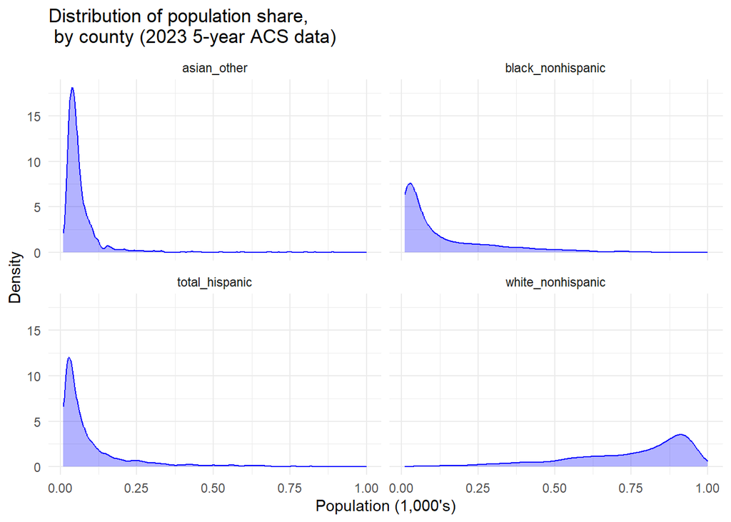

```r
year_viz <- wide_county_demo %>%
  filter(year == max(update_years)) %>%
  select(year) %>%
  unique() %>%
  pull()

wide_county_demo %>%
  filter(year == max(update_years)) %>%
  select(GEOID, asian_other, black_nonhispanic, total_hispanic, white_nonhispanic) %>%
  pivot_longer(-GEOID, names_to = "subgroup", values_to = "pop_shr") %>%
  filter(pop_shr > 0.01) %>%
  ggplot(aes(x = pop_shr)) +
  geom_density(color = "blue", fill = alpha("blue", 0.3)) +
  facet_wrap(~subgroup) +
  labs(
    title = paste0("Distribution of population share,\n by county (", year_viz, " 5-year ACS data)"),
    y = "Density",
    x = "Population (1,000's)"
  ) +
  theme_minimal()
```

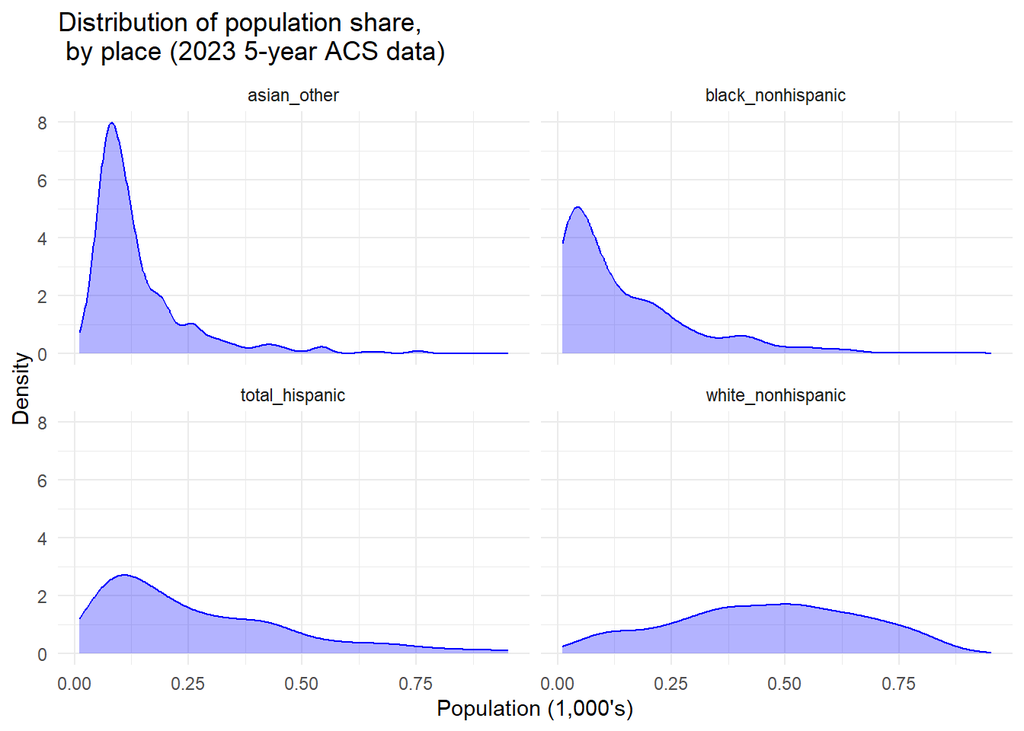

```r
wide_places_demo %>%
  filter(year == max(update_years)) %>%
  select(GEOID, asian_other, black_nonhispanic, total_hispanic, white_nonhispanic) %>%
  pivot_longer(-GEOID, names_to = "subgroup", values_to = "pop_shr") %>%
  filter(pop_shr > 0.01) %>%
  ggplot(aes(x = pop_shr)) +
  geom_density(color = "blue", fill = alpha("blue", 0.3)) +
  facet_wrap(~subgroup) +
  labs(
    title = paste0("Distribution of population share,\n by place (", year_viz, " 5-year ACS data)"),
    y = "Density",
    x = "Population (1,000's)"
  ) +
  theme_minimal()
```

Test to see if bounded by 0 and 1.

```r
stopifnot(
  wide_county_demo %>%
    filter(
      asian_other < 0 | asian_other > 1 |
        black_nonhispanic < 0 | black_nonhispanic > 1|
        total_hispanic < 0 | total_hispanic > 1 |
        white_nonhispanic < 0 | white_nonhispanic > 1
    ) %>%
    nrow() == 0
)

stopifnot(
  wide_places_demo %>%
    filter(
      asian_other < 0 | asian_other > 1 |
        black_nonhispanic < 0 | black_nonhispanic > 1|
        total_hispanic < 0 | total_hispanic > 1 |
        white_nonhispanic < 0 | white_nonhispanic > 1
    ) %>%
    nrow() == 0
)
```

If this is still running, we are good to proceed!

Test to see if the 4 categories sum to 1.

```r
stopifnot(
  wide_county_demo %>%
    mutate(total = round(asian_other + black_nonhispanic + total_hispanic + white_nonhispanic, 10)) %>%
    filter(total != 1) %>%
    nrow() == 0
)

stopifnot(
  wide_places_demo %>%
    mutate(total = round(asian_other + black_nonhispanic + total_hispanic + white_nonhispanic, 10)) %>%
    filter(total != 1) %>%
    nrow() == 0
)
```

If this is still running, we are good to proceed!

Show number of places available

```r
wide_places_demo %>%
  group_by(year) %>%
  count()
```

```
# A tibble: 5 x 2
# Groups:   year [5]
   year     n
  <dbl> <int>
1  2014   485
2  2016   485
3  2018   486
4  2021   486
5  2023   486
```

```r
wide_county_demo %>%
  group_by(year) %>%
  count()
```

```
# A tibble: 5 x 2
# Groups:   year [5]
   year     n
  <dbl> <int>
1  2014  3142
2  2016  3142
3  2018  3142
4  2021  3143
5  2023  3144
```

## Create quality flag

Because we use the census summary tables we can assume all data quality is good.

```r
wide_county_demo <- wide_county_demo %>%
  mutate(total_people_quality = 1, total_nonhisp_quality = 1, asian_other_quality = 1,
         black_nonhispanic_quality = 1, total_hispanic_quality = 1, white_nonhispanic_quality = 1)

wide_places_demo <- wide_places_demo %>%
  mutate(total_people_quality = 1, total_nonhisp_quality = 1, asian_other_quality = 1,
         black_nonhispanic_quality = 1, total_hispanic_quality = 1, white_nonhispanic_quality = 1)
```

## Prepare for Export and Test

Keep only relevant variables before export.

```r
county_pop_by_race <- wide_county_demo %>%
  select(year, state, county, other = asian_other, other_quality = asian_other_quality, black_nonhispanic,  black_nonhispanic_quality, hispanic = total_hispanic, hispanic_quality = total_hispanic_quality, white_nonhispanic, white_nonhispanic_quality)
```

Rename values.

```r
county_pop_by_race <- county_pop_by_race %>%
  rename_with(.cols = other:white_nonhispanic_quality,
              ~str_c("share_desc_rep_", .x))
```

Same process for place.

```r
place_pop_by_race <- wide_places_demo %>%
  select(year, state, place, other = asian_other, other_quality = asian_other_quality, black_nonhispanic,  black_nonhispanic_quality, hispanic = total_hispanic, hispanic_quality = total_hispanic_quality, white_nonhispanic, white_nonhispanic_quality)
```

```r
place_pop_by_race <- place_pop_by_race %>%
   rename_with(.cols = other:white_nonhispanic_quality,
              ~str_c("share_desc_rep_", .x))
```

### Final evaluation

Place data.

```r
evaluate_final_data(exp_form_path = here::here("10a_final-evaluation", "evaluation_form_desc_rep_overall_place.csv"), data = place_pop_by_race, geography = "place", subgroups = FALSE, confidence_intervals = FALSE)
```

```
[1] "This data passes all tests!"
```

County data.

```r
evaluate_final_data(exp_form_path = here::here("10a_final-evaluation", "evaluation_form_desc_rep_overall_county.csv"), data = county_pop_by_race, geography = "county", subgroups = FALSE, confidence_intervals = FALSE)
```

```
[1] "This data passes all tests!"
```

### Export as CSV

```r
write_csv(county_pop_by_race, here::here("22_descriptive-representation", "data", "final",
                                         paste0("descriptive_rep_denominator_county_all.csv")))

write_csv(place_pop_by_race, here::here("22_descriptive-representation", "data", "final",
                                        paste0("descriptive_rep_denominator_city_all.csv")))
```